# Lecture 3: Mathematical Operations and Random Numbers

In the previous class we:

- Introduced lists and variable types
- Talked about how to extract elements from a list

In this class we will:

- Introduce a library for general mathematical operations
- Generate random numbers
- (Optional) Matrix operations

## I. Import Libraries

```python
# the "numPy" library is used for mathematical operations on matrices, vectors, arrays
# the "matplotlib" library is for generating graphs

import numpy as np
import matplotlib.pyplot as plt
import math as math
```

[output not shown]

## II. Numbers and Functions

Examples of numPy numbers

```python
# Computes "pi" (3.14...)

np.pi # np = larger function
# .pi  = going to a sub function within that library
```

```
3.141592653589793
```

Examples of numPy functions

$ ln(x), e^x, sin(x), cos(x), \sqrt{x}$

```python
# log(x) computes the logarithm with base "e" (Euler constant)
# exp(x) compute the Euler constant raised to the power of "x"
# sing(x) computes the sine of x
# cos(x) computes the cosine of x
# In this example, we're substituting x = 1

print(np.log(1))
print(np.exp(1))
print(np.sin(1))
print(np.cos(1))
print(np.sqrt(1))
```

```
0.0
2.718281828459045
0.8414709848078965
0.5403023058681398
1.0
```

Raising to the power of a number

$ x^5 $

```python
x=2
print(x * 10)
print(x ** 5) # recall print function prevents it from omitting every line besides the bottom

# Not x^5
```

```
20
32
```

Try it yourself!

- Create a new variable, $x = 5$
- Compute $\pi x^2$
- Compute $ \frac{1}{\sqrt{2\pi}}e^{-x^2} $

```python
# Write your own code
```

[output not shown]

## III. Vector Arrays

Create an array from a list

$ \text{ }$ $ a = \begin{pmatrix} 1 \\ 2 \\ 3 \end{pmatrix} \qquad b = \begin{pmatrix} 0 \\ 1 \\ 0\end{pmatrix} \qquad c = \begin{pmatrix} 10 \\ 100 \\ 1000 \\ 2000 \\ 5000 \end{pmatrix} \qquad d = \begin{pmatrix} 4 \\ 2 \end{pmatrix} $

```python
# You create an array by converting a list [1,2,3] to a numeric object
# "array" is a subfunction of the library numPy.

vec_a  = np.array([1,2,3])
vec_b  = np.array([0,1,0])
vec_c  = np.array([10,100,1000,2000,5000 ])
```

Accessing an element of an array

```python
# Arrays, like lists, start their numbering at zero.
# You also access them with square brackets

print(vec_a[0]) # position starts at 0
print(vec_a[2])
```

```
1
3
```

Operations with a single array and a scalar

$ a + 2 = \begin{pmatrix} a_1 + 2 \\ a_2 + 2 \\ a_3 + 2 \end{pmatrix}$

```python
# A scalar refers to either an int or float
# We can do many common operations with

print(vec_a * 2) # does this to every single element in the matrix
print(vec_a / 2)
print(vec_a + 2)
print(vec_a ** 2)
```

```
[2 4 6]
[0.5 1.  1.5]
[3 4 5]
[1 4 9]
```

Element-by-element addition between two arrays of the same size

$\text{ }$

$ a + b = \begin{pmatrix} a_1 \\ a_2 \\ a_3 \end{pmatrix} + \begin{pmatrix} b_1 \\ b_2 \\ b_3 \end{pmatrix} = \begin{pmatrix} a_1 + b_1 \\ a_2 + b_2 \\ a_3 + b_3 \end{pmatrix}$

```python
print(vec_a)
print(vec_b)
```

```
[1 2 3]
[0 1 0]
```

```python
# When you add two arrays of the same size,
# Python adds the individual elements in each position

print(vec_a + vec_b)
```

```
[1 3 3]
```

The default multiplication option is element-by element:

$ a * b = \begin{pmatrix} a_1 * b_1 \\ a_2 * b_2 \\ a_3 * b_3 \end{pmatrix}$

```python
# We can do other similar element-by-element operations
# such as multiplication, subtraction, and division.

print(vec_a * vec_b)
print(vec_a - vec_b)
print(vec_a / vec_b)  # python treats division by zero like infinity
```

```
[0 2 0]
[1 1 3]
[inf  2. inf]
```

Summary statistics of an array

```python
# The function np.mean() computes the mean of an array
# We can do similar operations for the standard deviation (std),
# the minimum (min), the median (median), and the maximum (max).

print(np.std(vec_a)) # try changing values in the vector to see how this shifts
print(np.min(vec_a))
print(np.median(vec_a))
print(np.max(vec_a))

vec_d = np.array([1])
```

```
0.816496580927726
1
2.0
3
```

Try it yourself! Compute the median of

$ e = \begin{pmatrix} 10 \\ 8 \\ 15 \\ 0 \\ 24 \end{pmatrix} $

```python
# Create your own array and compute any of the above summary statistics

e = np.array( [10,8,15,0,24] )

np.median(e)
```

```
10.0
```

Common Pitfall : Make sure that the arrays have the same size

```python
print(vec_a)
print(vec_c)
```

```
[1 2 3]
[  10  100 1000 2000 5000]
```

```python
vec_a.shape # shows how big the array is

# (rows, columns)
```

```
(3,)
```

```python
# Here I try to combine two arrays of different size.

vec_a + vec_c #exmample of a controlled error
```

```
---------------------------------------------------------------------------
ValueError                                Traceback (most recent call last)
Cell In[24], line 3
      1 # Here I try to combine two arrays of different size.
----> 3 vec_a + vec_c

ValueError: operands could not be broadcast together with shapes (3,) (5,)
```

## IV. Random Numbers

Why randomness?

- Simulate different scenarios: high risk or low risk
- Study properties of a complex system and/or estimator
- In medicine, randomly assign subjects to treatment or control

Create a vector of random variables

```python
# This code creates a vector of random variables
# generated from a normal distribution with
# mean "loc" (location) and standard deviation "scale"
# the number of distinct variabels is "size"

randomvar_a = np.random.normal(loc=0, scale=1, size=10)
print(randomvar_a)
```

```
[ 1.20872922 -0.14077811 -0.33365123  0.29247472 -1.85913531 -1.17988654
 -0.85624028 -0.82051081 -2.02808527 -1.43143449]
```

Random numbers differ every time!

- Avoid this problem by drawing from a "pregenerated" set.
- This is called a seed

```python
# Your computer will typically generate different numbers every time you run a command
# However, sometimes you want to be able to replicate the results
# You can choose any other number instead of "12345". This will produce another set
# of random numbers, but they will give the same answers

np.random.seed(103931)

random_var_b = np.random.normal(loc=0, scale=1, size=10)

print(random_var_b)
```

[output not shown]

Compute a histogram with the results

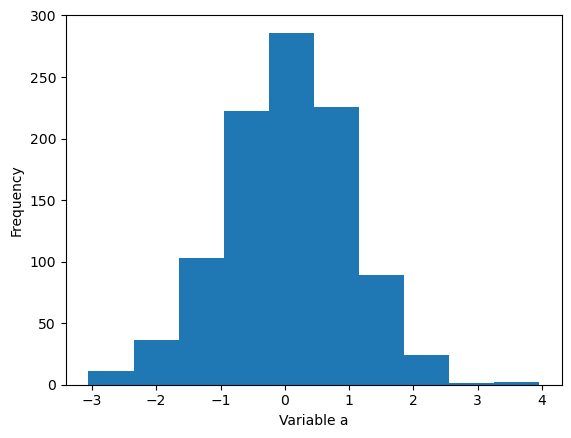

```python
# Compute a histogram
# You can edit the number of bins with plt.hist(x = randomvar_a)

randomvar_x = np.random.normal(loc=0, scale=1, size=1000) # scale = represents normal distribution.
# 2 types of normal distribution: unbounded and bounded.

# definition/verbalization: array and vector are interchangeably. aray is official python language.

plt.hist(x = randomvar_x)
plt.xlabel("Variable a")
plt.ylabel("Frequency")
```

Try this again with $size = 100, 1000, 10000$

[figure not shown]

```python
# Write the code for your histogram

# Compute a histogram
# You can edit the number of bins with plt.hist(x = randomvar_a)
```

# Additional Resources

Check out additional examples at:

- https://allendowney.github.io/ElementsOfDataScience/03_arrays.html

# (Optional) Matrix Operations

Creating a matrix by stacking different rows

$ \text{ }$

$ X = \begin{pmatrix} 1 & 2 & 3 \\ 0 & 4 & 5 \\ 0 & 0 & 6 \end{pmatrix} $

```python
# Matrices are usually denoted by capital letters
# The object [[1,2,3],[4,5,6],[7,8,9]] is a list of lists
# It's useful to maintain this notation in the code as well

X = np.array([[1,2,3],[0,4,5],[0,0,6]])
print(X)
```

```
[[1 2 3]
 [0 4 5]
 [0 0 6]]
```

Creating a matrix by stacking different columns

$ \text{ } $

$ Y = \begin{pmatrix} 1 & 2 \\ 0 & 1 \\ 1 & 0 \end{pmatrix}$

```python
# You can also stack columns
Y =  np.column_stack([[1,0,1],[2,1,0]])
print(Y)
```

[output not shown]

Transpose

$ \text{ }$

$ Y' = \begin{pmatrix} 1 & 0 & 1 \\ 2 & 1 & 0 \end{pmatrix} $

```python
# Matrix Transpose
np.matrix.transpose(Y)
```

[output not shown]

Matrix multiplication

$ XY = \begin{pmatrix} 1 & 2 & 3 \\ 0 & 4 & 5 \\ 0 & 0 & 6 \end{pmatrix} \begin{pmatrix} 1 & 2 \\ 0 & 1 \\ 1 & 0 \end{pmatrix} = \begin{pmatrix} 4 & 4 \\ 5 & 4 \\ 6 & 0 \end{pmatrix} $

```python
# Matrix Multiplication

np.dot(X,Y)

np.matmul(X,Y)
```

[output not shown]

Matrix inverse

$ X^{-1} = \begin{pmatrix} 1 & 2 & 3 \\ 0 & 4 & 5 \\ 0 & 0 & 6 \end{pmatrix}^{-1} $

```python
# Check the determinant of a matrix (a matrix is invertible if the determinant is not zero)
print(np.linalg.det(X))

# Matrix inverse
# The following command stands for linear algebrar inverse.
X_inv = np.linalg.inv(X)

# Output the result
print(X_inv)
```

[output not shown]

Try it yourself! Check that this is indeed an inverse:

$X X_{inv} = \begin{pmatrix} 1 & 0 & 0 \\ 0 & 1 & 0 \\ 0 & 0 & 1 \end{pmatrix}$

```python
# Multiply "X" times "X_inv" using the command shown above
# Note: Sometimes the result is shown in scientific notation.
```